# COVID19-Project

Grant Bitner

2023-06-24

After three years of around-the-clock tracking of COVID-19 data from around the world, Johns Hopkins has discontinued the Coronavirus Resource Center’s operations. The site’s two raw data repositories will remain accessible for information collected from 1/22/20 to 3/10/23 on cases, deaths, vaccines, testing and demographics.

```r
library(tidyverse)
library(dplyr)
library(lubridate)
library(readr)
library(ggplot2)
```

## Load and Tidy Data

```r
url_in <- "https://raw.githubusercontent.com/CSSEGISandData/COVID-19/4360e50239b4eb6b22f3a1759323748f36752177/csse_covid_19_data/csse_covid_19_time_series/"
file_names <- c("time_series_covid19_confirmed_global.csv",
                "time_series_covid19_deaths_global.csv")
urls <- str_c(url_in, file_names)
global_cases <- read_csv(urls[1])
global_deaths <- read_csv(urls[2])
```

```r
global_cases <- global_cases %>%
  pivot_longer(cols = -c('Province/State',
                         'Country/Region', Lat, Long),
               names_to = "date",
               values_to = "cases") %>%
  select(-c(Lat, Long))

global_deaths <- global_deaths %>%
  pivot_longer(cols = -c('Province/State',
                         'Country/Region', Lat, Long),
               names_to = "date",
               values_to = "cases") %>%
  select(-c(Lat, Long))

global <- full_join(global_cases, global_deaths,
                    by = c("Province/State", "Country/Region", "date")) %>%
  rename(Province_State = "Province/State",
         Country_Region = "Country/Region",
         cases = cases.x,
         deaths = cases.y) %>%
  mutate(date = mdy(date))

global_amended <- global %>%
  filter(cases > 1000000)

head(global)
```

```
## # A tibble: 6 × 5
##   Province_State Country_Region date       cases deaths
##   <chr>          <chr>          <date>     <dbl>  <dbl>
## 1 <NA>           Afghanistan    2020-01-22     0      0
## 2 <NA>           Afghanistan    2020-01-23     0      0
## 3 <NA>           Afghanistan    2020-01-24     0      0
## 4 <NA>           Afghanistan    2020-01-25     0      0
## 5 <NA>           Afghanistan    2020-01-26     0      0
## 6 <NA>           Afghanistan    2020-01-27     0      0
```

## Data analysis and Visualization

First I created a stacked bar graph with cases and deaths by country. I filtered the data to only include countries with cases over 1,000,000 in this graph to limit cluttering of countries will low cases. It is important to note that this has not been normalized by a countries population and is simply number of cases/deaths.

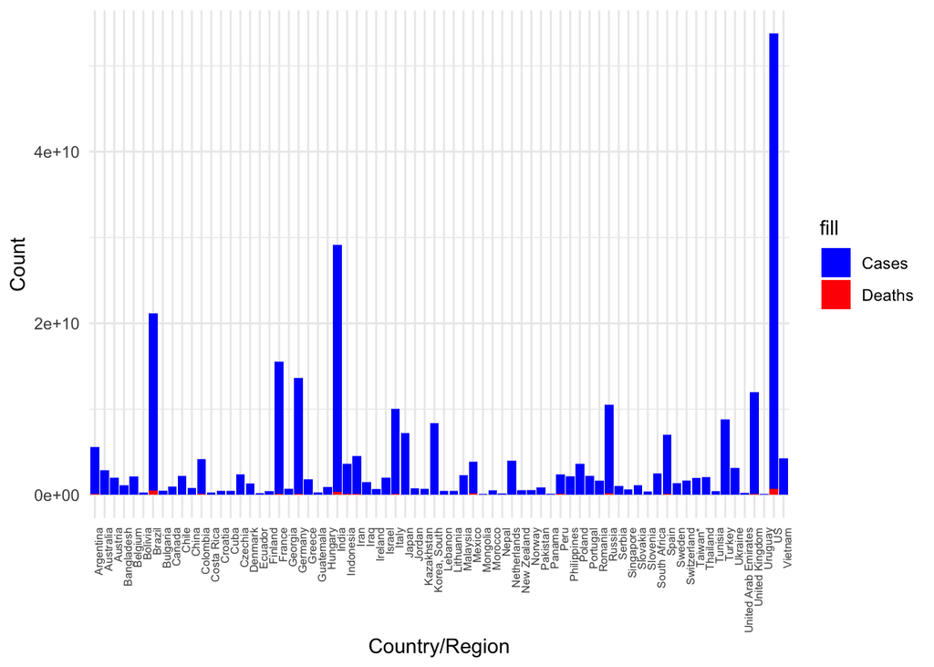

```r
global$Date <- as.Date(global$date)

ggplot(global_amended, aes(x = Country_Region)) +
  geom_bar(aes(y = cases, fill = "Cases"), stat = "identity") +
  geom_bar(aes(y = deaths, fill = "Deaths"), stat = "identity") +
  labs(x = "Country/Region", y = "Count") +
  scale_fill_manual(values = c("Cases" = "blue", "Deaths" = "red")) +
  theme_minimal() +
  theme(axis.text.x = element_text(angle = 90, hjust = 1, size = 6))
```

Here I created a simple time series of cases per date. This allows us to witness the sharp increases in cases as well as periods of slowed growth. I made sure to revert the filtering cases below a million back to any cases above 0 for the remainder of the report.

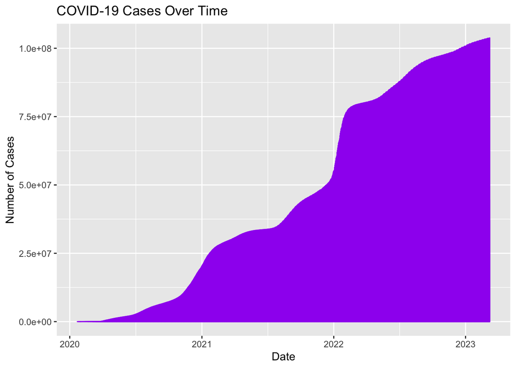

```r
global <- global %>%
  filter(cases > 0)

ggplot(global, aes(x = date, y = cases)) +
  geom_line(color = "purple") +
  labs(title = "COVID-19 Cases Over Time",
       x = "Date",
       y = "Number of Cases")
```

Similarly here is a time series of deaths plotted against time. You will notice they have a similar trend as cases.

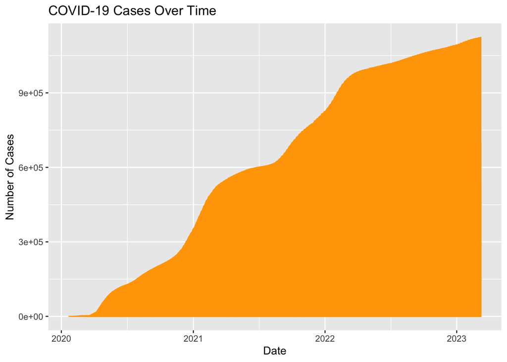

```r
ggplot(global, aes(x = date, y = deaths)) +
  geom_line(color = "orange") +
  labs(title = "COVID-19 Cases Over Time",
       x = "Date",
       y = "Number of Cases")
```

Here I created a basic table to compare mortality rates between countries.

```r
mortality_table <- global %>%
  group_by(Country_Region) %>%
  summarise(
    Total_Cases = sum(cases),
    Total_Deaths = sum(deaths),
    Mortality_Rate = Total_Deaths / Total_Cases * 100
  )

print(mortality_table)
```

```
## # A tibble: 201 × 4
##    Country_Region      Total_Cases Total_Deaths Mortality_Rate
##    <chr>                     <dbl>        <dbl>          <dbl>
##  1 Afghanistan           129988469      5421435          4.17
##  2 Albania               185562654      2485380          1.34
##  3 Algeria               182741650      4901275          2.68
##  4 Andorra                24547525       127190          0.518
##  5 Angola                 60025203      1231834          2.05
##  6 Antarctica                 4961            0          0
##  7 Antigua and Barbuda     4310255        80291          1.86
##  8 Argentina            5625482921     91037145          1.62
##  9 Armenia               285491323      5705393          2.00
## 10 Australia            3508864881      5590832          0.159
## # ℹ 191 more rows
```

Finally I wanted to look at the countries with the top 10 mortality rates, as well as those with the bottom 10 mortality rates.

```r
sorted_table <- arrange(mortality_table, Mortality_Rate)

lowest_mortality <- head(sorted_table, n = 10)

highest_mortality <- tail(sorted_table, n = 10)

cat("Top 10 Lowest Mortality Rates:\n")
```

```
## Top 10 Lowest Mortality Rates:
```

```r
print(lowest_mortality)
```

```
## # A tibble: 10 × 4
##    Country_Region       Total_Cases Total_Deaths Mortality_Rate
##    <chr>                      <dbl>        <dbl>          <dbl>
##  1 Antarctica                  4961            0         0
##  2 Holy See                   26807            0         0
##  3 Summer Olympics 2020      498688            0         0
##  4 Tuvalu                    322901            0         0
##  5 Winter Olympics 2022      214462            0         0
##  6 Nauru                    1184912          251         0.0212
##  7 Bhutan                  22329795         8214         0.0368
##  8 Tonga                    4975228         4140         0.0832
##  9 Singapore              723549534       691223         0.0955
## 10 Burundi                 23149109        23631         0.102
```

```r
cat("\nTop 10 Highest Mortality Rates:\n")
```

```
##
## Top 10 Highest Mortality Rates:
```

```r
print(highest_mortality)
```

```
## # A tibble: 10 × 4
##    Country_Region Total_Cases Total_Deaths Mortality_Rate
##    <chr>                <dbl>        <dbl>          <dbl>
##  1 Ecuador          584150381     26441796           4.53
##  2 Somalia           17864013       897718           5.03
##  3 Egypt            334600873     17248941           5.16
##  4 Syria             35209217      2062701           5.86
##  5 Mexico          3944108014    241085189           6.11
##  6 Peru            2499413018    170749849           6.83
##  7 Sudan             42936981      3180915           7.41
##  8 Yemen              7879435      1515446          19.2
##  9 MS Zaandam            9665         2146          22.2
## 10 Korea, North           300         1800         600
```

## Identify Bias

First I will identify some of my own bias. I live in the US so naturally could be influenced by my own experiences when analyzing the data. I chose to look at the world as a whole instead of the US more specifically to limit this.

There is certainly a reporting bias that must be taken into consider between countries. Some countries are going to have more accurate reporting than others which can result in the data fluctuating in both directions. Additionally some countries could have potentially under reported their own cases and deaths to downplay the severity in the respective country for political reasons.